# Practical Machine Learning Course Project

Niraj Yadav

January 8, 2017

First let’s download and load data files

```r
train_URL <- "https://d396qusza40orc.cloudfront.net/predmachlearn/pml-training.csv"
test_URL <- "https://d396qusza40orc.cloudfront.net/predmachlearn/pml-testing.csv"
#download.file(train_URL,destfile = "./data/pml-training.csv")
#download.file(test_URL,destfile = "./data/pml-test.csv")
train <- read.csv("./data/pml-training.csv",na.strings=c("NA","#DIV/0!", ""))
test <- read.csv("./data/pml-test.csv",na.strings=c("NA","#DIV/0!", ""))
```

Let’s look at data

```r
dim(train)
```

```
## [1] 19622   160
```

```r
dim(test)
```

```
## [1]  20 160
```

```r
head(train)
```

```
##   X user_name raw_timestamp_part_1 raw_timestamp_part_2   cvtd_timestamp
## 1 1  carlitos           1323084231               788290 05/12/2011 11:23
## 2 2  carlitos           1323084231               808298 05/12/2011 11:23
## 3 3  carlitos           1323084231               820366 05/12/2011 11:23
## 4 4  carlitos           1323084232               120339 05/12/2011 11:23
## 5 5  carlitos           1323084232               196328 05/12/2011 11:23
## 6 6  carlitos           1323084232               304277 05/12/2011 11:23
##   new_window num_window roll_belt pitch_belt yaw_belt total_accel_belt
## 1         no         11      1.41       8.07    -94.4                3
## 2         no         11      1.41       8.07    -94.4                3
## 3         no         11      1.42       8.07    -94.4                3
## 4         no         12      1.48       8.05    -94.4                3
## 5         no         12      1.48       8.07    -94.4                3
## 6         no         12      1.45       8.06    -94.4                3
##   kurtosis_roll_belt kurtosis_picth_belt kurtosis_yaw_belt
```

[output cut: 265 more lines]

```r
train<-train[,colSums(is.na(train)) == 0]
test <-test[,colSums(is.na(test)) == 0]
```

Remove irrelevant variables for this project. Column 1 to 7. i.e. user_name, raw_timestamp_part_1, raw_timestamp_part_2, cvtd_timestamp, new_window, and num_window

```r
train   <-train[,-c(1:7)]
test <- test[,-c(1:7)]
```

This is our final data set after removing noise

```r
dim(train)
```

```
## [1] 19622    53
```

```r
dim(test)
```

```
## [1] 20 53
```

```r
head(train)
```

```
##   roll_belt pitch_belt yaw_belt total_accel_belt gyros_belt_x gyros_belt_y
## 1      1.41       8.07    -94.4                3         0.00         0.00
## 2      1.41       8.07    -94.4                3         0.02         0.00
## 3      1.42       8.07    -94.4                3         0.00         0.00
## 4      1.48       8.05    -94.4                3         0.02         0.00
## 5      1.48       8.07    -94.4                3         0.02         0.02
## 6      1.45       8.06    -94.4                3         0.02         0.00
##   gyros_belt_z accel_belt_x accel_belt_y accel_belt_z magnet_belt_x
## 1        -0.02          -21            4           22            -3
## 2        -0.02          -22            4           22            -7
## 3        -0.02          -20            5           23            -2
## 4        -0.03          -22            3           21            -6
## 5        -0.02          -21            2           24            -6
## 6        -0.02          -21            4           21             0
##   magnet_belt_y magnet_belt_z roll_arm pitch_arm yaw_arm total_accel_arm
```

[output cut: 69 more lines]

Let’s partition training data in to training and test sample for prediction algorithm.

```r
library(caret)
set.seed(33213)
subData <- createDataPartition(y=train$classe, p=0.75, list=FALSE)
S_Training <- train[subData, ]
S_Testing <- train[-subData, ]
dim(S_Training)
```

```
## [1] 14718    53
```

```r
dim(S_Testing)
```

```
## [1] 4904   53
```

Let’s look at our data. Below plot shows frequency of our predictor variable in training set

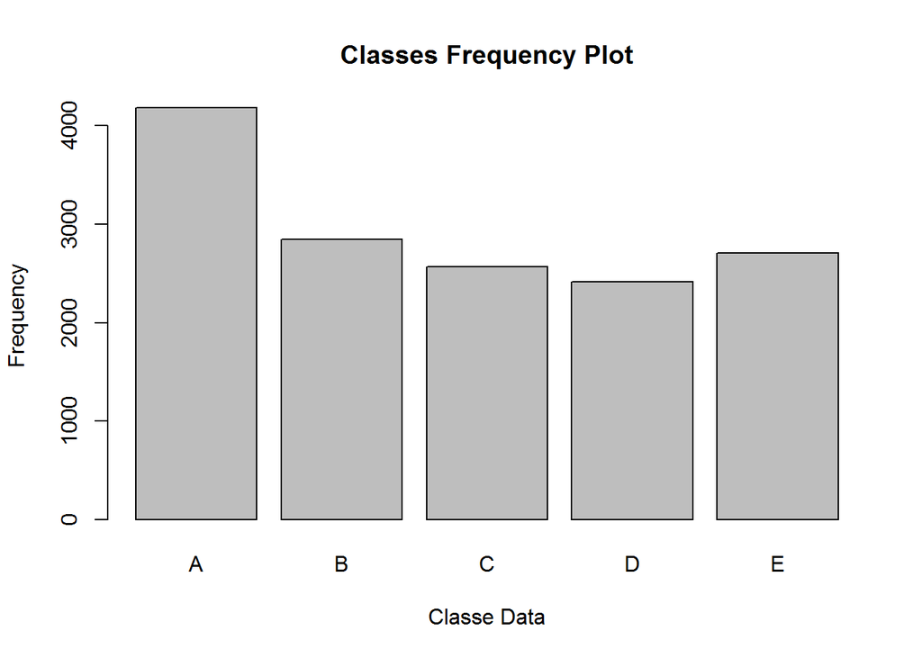

```r
plot(S_Training$classe,xlab="Classe Data",ylab="Frequency",main="Classes Frequency Plot")
```

Let’s start prediction. We will do our first prediction using random forest.

```r
library(randomForest)
model_rf <- randomForest(classe ~. , data=S_Training, method="class")
predict_rf <- predict(model_rf, S_Testing, type = "class")
confusionMatrix(predict_rf, S_Testing$classe)
```

```
## Confusion Matrix and Statistics
##
##           Reference
## Prediction    A    B    C    D    E
##          A 1395    6    0    0    0
##          B    0  940    3    0    0
##          C    0    3  850    6    0
##          D    0    0    2  798    3
##          E    0    0    0    0  898
##
## Overall Statistics
##
##                Accuracy : 0.9953
##                  95% CI : (0.993, 0.997)
##     No Information Rate : 0.2845
##     P-Value [Acc > NIR] : < 2.2e-16
##
##                   Kappa : 0.9941
##  Mcnemar's Test P-Value : NA
##
## Statistics by Class:
##
##                      Class: A Class: B Class: C Class: D Class: E
## Sensitivity            1.0000   0.9905   0.9942   0.9925   0.9967
## Specificity            0.9983   0.9992   0.9978   0.9988   1.0000
## Pos Pred Value         0.9957   0.9968   0.9895   0.9938   1.0000
## Neg Pred Value         1.0000   0.9977   0.9988   0.9985   0.9993
## Prevalence             0.2845   0.1935   0.1743   0.1639   0.1837
## Detection Rate         0.2845   0.1917   0.1733   0.1627   0.1831
## Detection Prevalence   0.2857   0.1923   0.1752   0.1637   0.1831
## Balanced Accuracy      0.9991   0.9949   0.9960   0.9957   0.9983
```

Above data shows accurracy of prediction with random forest model.

Let’s model same data with Decision based tree

```r
library(rattle)
model_rpart <- train(classe ~ ., data=S_Training, method="rpart")
predict_rpart <- predict(model_rpart, S_Testing)
```

Let’s plot decision tree model to visualize it.

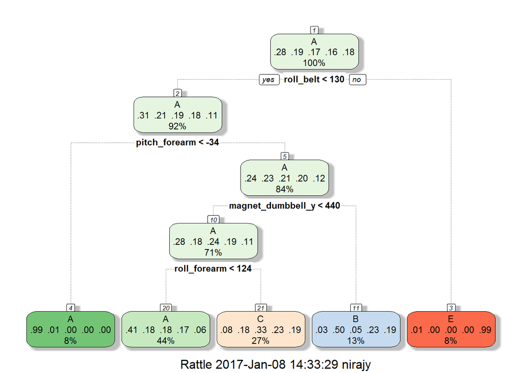

```r
library(rattle)
fancyRpartPlot(model_rpart$finalModel)
```

Let’s look at accurracy of prediction for Decision tree based model

```r
confusionMatrix(predict_rpart, S_Testing$classe)
```

```
## Confusion Matrix and Statistics
##
##           Reference
## Prediction    A    B    C    D    E
##          A 1265  386  405  382  128
##          B   20  329   22  128  126
##          C  107  234  428  294  234
##          D    0    0    0    0    0
##          E    3    0    0    0  413
##
## Overall Statistics
##
##                Accuracy : 0.4965
##                  95% CI : (0.4824, 0.5106)
##     No Information Rate : 0.2845
##     P-Value [Acc > NIR] : < 2.2e-16
##
##                   Kappa : 0.3417
##  Mcnemar's Test P-Value : NA
##
## Statistics by Class:
##
##                      Class: A Class: B Class: C Class: D Class: E
## Sensitivity            0.9068  0.34668  0.50058   0.0000  0.45838
## Specificity            0.6292  0.92516  0.78538   1.0000  0.99925
## Pos Pred Value         0.4930  0.52640  0.32999      NaN  0.99279
## Neg Pred Value         0.9444  0.85511  0.88162   0.8361  0.89127
## Prevalence             0.2845  0.19352  0.17435   0.1639  0.18373
## Detection Rate         0.2580  0.06709  0.08728   0.0000  0.08422
## Detection Prevalence   0.5232  0.12745  0.26448   0.0000  0.08483
## Balanced Accuracy      0.7680  0.63592  0.64298   0.5000  0.72882
```

## Conclusion

Based on above Model Random Forest algorithm did better than Decision Trees. Accurracy of random forest is much better. Accuracy for Random Forest model: 0.9953 (95% CI: (0.993, 0.997)) Accurracy for Decision Tree model: 0.4965 (95% CI: (0.4824, 0.5106))

Let’s run this on our test data

```r
predict_testrf <- predict(model_rf,test)
predict_testrf
```

```
##  1  2  3  4  5  6  7  8  9 10 11 12 13 14 15 16 17 18 19 20
##  B  A  B  A  A  E  D  B  A  A  B  C  B  A  E  E  A  B  B  B
## Levels: A B C D E
```